# Practical Machine Learning - Prediction Assignment Writeup

Benjamin Eggart

19th of July 2021

### 2. R Libraries that are used

```r
library(knitr)
library(caret)
library(rpart)
library(rpart.plot)
library(rattle)
library(randomForest)
library(corrplot)
library(e1071)
library(gbm)
set.seed(123)
```

### 3. Getting, Loading and Cleaning the Data

Get the data.

```r
# Download the dataset
Train <- "http://d396qusza40orc.cloudfront.net/predmachlearn/pml-training.csv"
Test  <- "http://d396qusza40orc.cloudfront.net/predmachlearn/pml-testing.csv"
```

Load the data and split it in training and test data.

```r
# Read thedata
training <- read.csv(url(Train))
testing  <- read.csv(url(Test))

# create training dataset with 70% of the data
train_part  <- createDataPartition(training$classe, p=0.7, list=FALSE)
TrainSet <- training[train_part, ]
TestSet  <- training[-train_part, ]
dim(TrainSet)
```

[output not shown]

The training data set is made of 19622 observations on 160 columns. The first seven columns give information about the people who did the test. They also provide a timestamps but this is ignored. Remove NAs.

```r
# Get the indexes of the columns having at least 90% of NA or blank values on the training data
indColToRemove <- which(colSums(is.na(TrainSet) |TrainSet=="")>0.9*dim(TrainSet)[1])
TrainSetClean <- TrainSet[,-indColToRemove]
TrainSetClean <- TrainSetClean[,-c(1:7)]
dim(TrainSetClean)
```

[output not shown]

```r
# Get the indexes of the columns having at least 90% of NA or blank values on the test data
indColToRemove <- which(colSums(is.na(TestSet) |TestSet=="")>0.9*dim(TestSet)[1])
TestSetClean <- TestSet[,-indColToRemove]
TestSetClean <- TestSetClean[,-1]
dim(TestSetClean)
```

```
## [1] 5885   59
```

### 4. Where are the correlations?

Before having a modeling procedure a correlation among variables is performed.

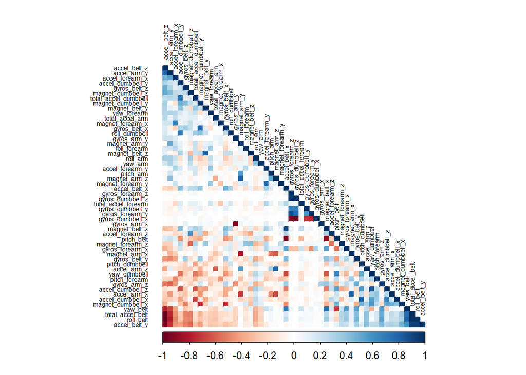

```r
corMatrix <- cor(TrainSetClean[, -53])
corrplot(corMatrix, order = "FPC", method = "color", type = "lower",
         tl.cex = 0.5, tl.offset =1,  tl.col = rgb(0, 0, 0))
```

### 5. Prediction Models

Three methods will be applied to model regressions with the Train dataset. The best one (highest accuracy for the Test dataset) will be used for the project predictions. (1) Random Forests, (2) Decision Tree and (3) Generalized Boosted Model are investigated. A Confusion Matrix is plotted for each analysis to better visualize the accuracy of the models.

### 5.1 Random Forest

```r
set.seed(123)
controlRF <- trainControl(method="cv", number=3, verboseIter=FALSE)
modFitRandForest <- train(classe ~ ., data=TrainSetClean, method="rf",
                          trControl=controlRF)
modFitRandForest$finalModel
```

```
##
## Call:
##  randomForest(x = x, y = y, mtry = min(param$mtry, ncol(x)))
##                Type of random forest: classification
##                      Number of trees: 500
## No. of variables tried at each split: 27
##
##         OOB estimate of  error rate: 0.74%
## Confusion matrix:
##      A    B    C    D    E class.error
## A 3898    4    3    0    1 0.002048131
## B   18 2631    9    0    0 0.010158014
## C    0   16 2370   10    0 0.010851419
## D    0    0   27 2223    2 0.012877442
## E    0    1    3    7 2514 0.004356436
```

```r
# prediction and confusion matrix on Test dataset
predictRandForest <- predict(modFitRandForest, newdata=TestSetClean)
confMatRandForest <- confusionMatrix(table(predictRandForest, TestSetClean$classe))
confMatRandForest
```

```
## Confusion Matrix and Statistics
##
##
## predictRandForest    A    B    C    D    E
##                 A 1674    6    0    0    0
##                 B    0 1126    5    0    0
##                 C    0    7 1019   10    4
##                 D    0    0    2  954    5
##                 E    0    0    0    0 1073
##
## Overall Statistics
##
##                Accuracy : 0.9934
##                  95% CI : (0.991, 0.9953)
##     No Information Rate : 0.2845
##     P-Value [Acc > NIR] : < 2.2e-16
##
##                   Kappa : 0.9916
##
##  Mcnemar's Test P-Value : NA
##
## Statistics by Class:
##
##                      Class: A Class: B Class: C Class: D Class: E
## Sensitivity            1.0000   0.9886   0.9932   0.9896   0.9917
## Specificity            0.9986   0.9989   0.9957   0.9986   1.0000
## Pos Pred Value         0.9964   0.9956   0.9798   0.9927   1.0000
## Neg Pred Value         1.0000   0.9973   0.9986   0.9980   0.9981
## Prevalence             0.2845   0.1935   0.1743   0.1638   0.1839
## Detection Rate         0.2845   0.1913   0.1732   0.1621   0.1823
## Detection Prevalence   0.2855   0.1922   0.1767   0.1633   0.1823
## Balanced Accuracy      0.9993   0.9938   0.9944   0.9941   0.9958
```

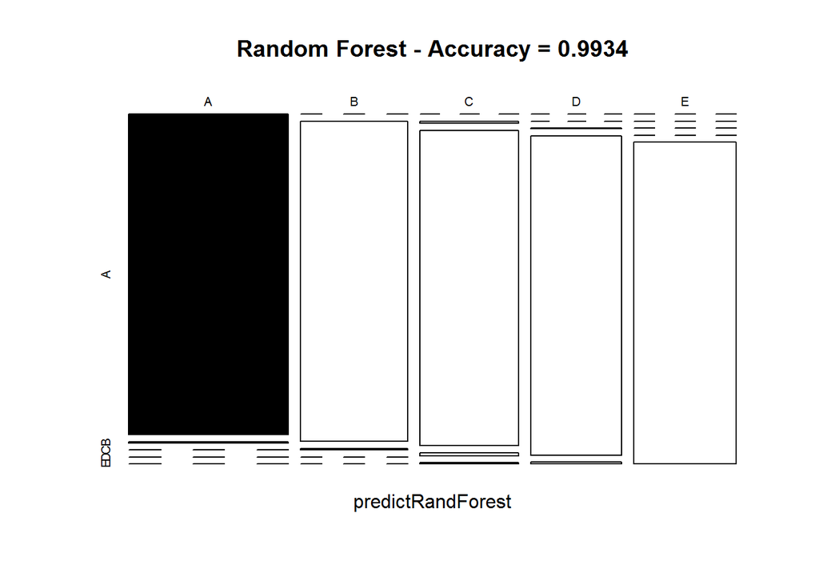

```r
# plot the results of the matrix
plot(confMatRandForest$table, col = confMatRandForest$byClass,
     main = paste("Random Forest - Accuracy =",
                  round(confMatRandForest$overall['Accuracy'], 4)))
```

### 5.2 Decision Tree

```r
set.seed(123)
modFitDecTree <- rpart(classe ~ ., data=TrainSetClean, method="class")

# prediction on Test dataset
predictDecTree <- predict(modFitDecTree, newdata=TestSetClean, type="class")
confMatDecTree <- confusionMatrix(table(predictDecTree, TestSetClean$classe))
confMatDecTree
```

```
## Confusion Matrix and Statistics
##
##
## predictDecTree    A    B    C    D    E
##              A 1552  174   18   60    6
##              B   48  588   43   63   64
##              C   39  220  888  100  148
##              D   24   83   75  651   86
##              E   11   74    2   90  778
##
## Overall Statistics
##
##                Accuracy : 0.7573
##                  95% CI : (0.7462, 0.7683)
##     No Information Rate : 0.2845
##     P-Value [Acc > NIR] : < 2.2e-16
##
##                   Kappa : 0.6926
##
##  Mcnemar's Test P-Value : < 2.2e-16
##
## Statistics by Class:
##
##                      Class: A Class: B Class: C Class: D Class: E
## Sensitivity            0.9271  0.51624   0.8655   0.6753   0.7190
## Specificity            0.9387  0.95407   0.8957   0.9455   0.9631
## Pos Pred Value         0.8575  0.72953   0.6366   0.7084   0.8147
## Neg Pred Value         0.9701  0.89151   0.9693   0.9370   0.9383
## Prevalence             0.2845  0.19354   0.1743   0.1638   0.1839
## Detection Rate         0.2637  0.09992   0.1509   0.1106   0.1322
## Detection Prevalence   0.3076  0.13696   0.2370   0.1562   0.1623
## Balanced Accuracy      0.9329  0.73515   0.8806   0.8104   0.8411
```

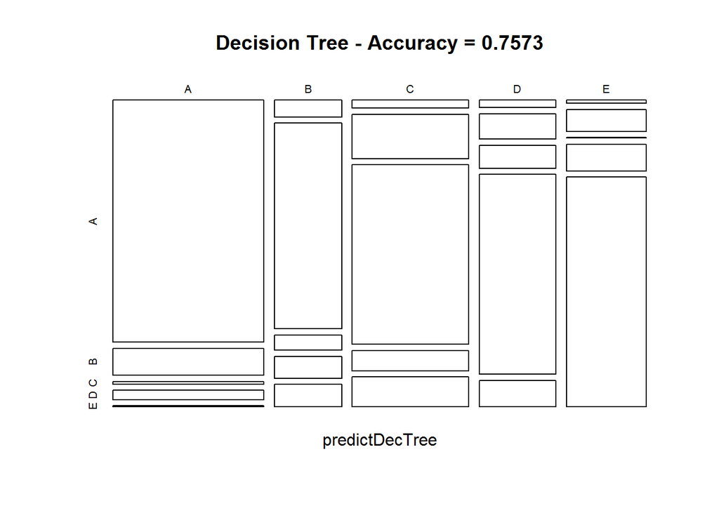

```r
# plot matrix results
plot(confMatDecTree$table, col = confMatDecTree$byClass,
     main = paste("Decision Tree - Accuracy =",
                  round(confMatDecTree$overall['Accuracy'], 4)))
```

### 5.3 Generalized Boosted Model

```r
set.seed(123)
controlGBM <- trainControl(method = "repeatedcv", number = 5, repeats = 1)
modFitGBM  <- train(classe ~ ., data=TrainSetClean, method = "gbm",
                    trControl = controlGBM, verbose = FALSE)

# prediction on Test dataset
predictGBM <- predict(modFitGBM, newdata=TestSetClean)
confMatGBM <- confusionMatrix(table(predictGBM, TestSetClean$classe))
confMatGBM
```

```
## Confusion Matrix and Statistics
##
##
## predictGBM    A    B    C    D    E
##          A 1649   26    0    2    3
##          B   17 1078   29    8    7
##          C    5   35  983   28   20
##          D    2    0   12  917   17
##          E    1    0    2    9 1035
##
## Overall Statistics
##
##                Accuracy : 0.9621
##                  95% CI : (0.9569, 0.9668)
##     No Information Rate : 0.2845
##     P-Value [Acc > NIR] : < 2.2e-16
##
##                   Kappa : 0.9521
##
##  Mcnemar's Test P-Value : 9.305e-07
##
## Statistics by Class:
##
##                      Class: A Class: B Class: C Class: D Class: E
## Sensitivity            0.9851   0.9464   0.9581   0.9512   0.9566
## Specificity            0.9926   0.9871   0.9819   0.9937   0.9975
## Pos Pred Value         0.9815   0.9464   0.9178   0.9673   0.9885
## Neg Pred Value         0.9941   0.9871   0.9911   0.9905   0.9903
## Prevalence             0.2845   0.1935   0.1743   0.1638   0.1839
## Detection Rate         0.2802   0.1832   0.1670   0.1558   0.1759
## Detection Prevalence   0.2855   0.1935   0.1820   0.1611   0.1779
## Balanced Accuracy      0.9889   0.9668   0.9700   0.9725   0.9770
```

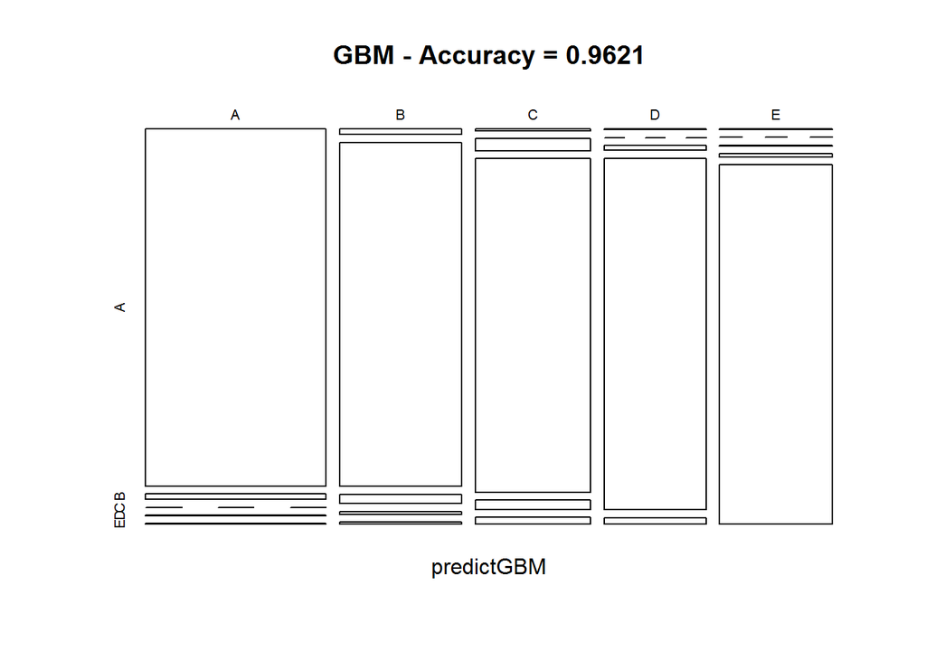

```r
# plot matrix results
plot(confMatGBM$table, col = confMatGBM$byClass,
     main = paste("GBM - Accuracy =", round(confMatGBM$overall['Accuracy'], 4)))
```

### 6. The Selected Model to the Test Data

The accuracy of the three regression models shown above are:

Random Forest = 0.9934, Decision Tree = 0.7573 Generalize Boosted Model = 0.9621. Of course, Random Forest model will be applied to predict the 20 quiz results on testing dataset as shown below.

```r
# plot matrix results
predictTEST <- predict(modFitRandForest, newdata=testing)
predictTEST
```

```
##  [1] B A B A A E D B A A B C B A E E A B B B
## Levels: A B C D E
```